# Risk Factor Analysis

## Outcome Variable

**Outcome Variable:** dead

## Predictor Variables

**Intervention Variable:** pers_wasted024

**Adjustment Set:**

- sex
- arm
- brthmon
- vagbrth
- hhwealth_quart
- W_mage
- W_mhtcm
- W_mwtkg
- W_mbmi
- W_meducyrs
- W_feducyrs
- W_nrooms
- W_parity
- impsan
- safeh20
- delta_vagbrth
- delta_hhwealth_quart
- delta_W_mage
- delta_W_mhtcm
- delta_W_mwtkg
- delta_W_mbmi
- delta_W_meducyrs
- delta_W_feducyrs
- delta_W_nrooms
- delta_W_parity
- delta_impsan
- delta_safeh20

## Stratifying Variables

The analysis was stratified on these variable(s):

- studyid
- country

## Data Summary

| studyid | country | pers_wasted024 | dead | n_cell | n | outcome_variable |
| --- | --- | --- | --- | --- | --- | --- |
| Burkina Faso Zn | BURKINA FASO | 0 | 0 | 6025 | 7166 | dead |
| Burkina Faso Zn | BURKINA FASO | 0 | 1 | 25 | 7166 | dead |
| Burkina Faso Zn | BURKINA FASO | 1 | 0 | 1102 | 7166 | dead |
| Burkina Faso Zn | BURKINA FASO | 1 | 1 | 14 | 7166 | dead |
| EE | PAKISTAN | 0 | 0 | 342 | 380 | dead |
| EE | PAKISTAN | 0 | 1 | 4 | 380 | dead |
| EE | PAKISTAN | 1 | 0 | 34 | 380 | dead |
| EE | PAKISTAN | 1 | 1 | 0 | 380 | dead |
| GMS-Nepal | NEPAL | 0 | 0 | 580 | 686 | dead |
| GMS-Nepal | NEPAL | 0 | 1 | 5 | 686 | dead |
| GMS-Nepal | NEPAL | 1 | 0 | 99 | 686 | dead |
| GMS-Nepal | NEPAL | 1 | 1 | 2 | 686 | dead |
| iLiNS-DOSE | MALAWI | 0 | 0 | 1744 | 1931 | dead |
| iLiNS-DOSE | MALAWI | 0 | 1 | 120 | 1931 | dead |
| iLiNS-DOSE | MALAWI | 1 | 0 | 59 | 1931 | dead |
| iLiNS-DOSE | MALAWI | 1 | 1 | 8 | 1931 | dead |
| iLiNS-DYAD-M | MALAWI | 0 | 0 | 1141 | 1201 | dead |
| iLiNS-DYAD-M | MALAWI | 0 | 1 | 33 | 1201 | dead |
| iLiNS-DYAD-M | MALAWI | 1 | 0 | 22 | 1201 | dead |
| iLiNS-DYAD-M | MALAWI | 1 | 1 | 5 | 1201 | dead |
| JiVitA-3 | BANGLADESH | 0 | 0 | 24625 | 26956 | dead |
| JiVitA-3 | BANGLADESH | 0 | 1 | 444 | 26956 | dead |
| JiVitA-3 | BANGLADESH | 1 | 0 | 1768 | 26956 | dead |
| JiVitA-3 | BANGLADESH | 1 | 1 | 119 | 26956 | dead |
| JiVitA-4 | BANGLADESH | 0 | 0 | 4955 | 5443 | dead |
| JiVitA-4 | BANGLADESH | 0 | 1 | 39 | 5443 | dead |
| JiVitA-4 | BANGLADESH | 1 | 0 | 439 | 5443 | dead |
| JiVitA-4 | BANGLADESH | 1 | 1 | 10 | 5443 | dead |
| Keneba | GAMBIA | 0 | 0 | 2662 | 2920 | dead |
| Keneba | GAMBIA | 0 | 1 | 53 | 2920 | dead |
| Keneba | GAMBIA | 1 | 0 | 196 | 2920 | dead |
| Keneba | GAMBIA | 1 | 1 | 9 | 2920 | dead |
| MAL-ED | BANGLADESH | 0 | 0 | 246 | 263 | dead |
| MAL-ED | BANGLADESH | 0 | 1 | 2 | 263 | dead |
| MAL-ED | BANGLADESH | 1 | 0 | 15 | 263 | dead |
| MAL-ED | BANGLADESH | 1 | 1 | 0 | 263 | dead |
| MAL-ED | INDIA | 0 | 0 | 226 | 251 | dead |
| MAL-ED | INDIA | 0 | 1 | 2 | 251 | dead |
| MAL-ED | INDIA | 1 | 0 | 23 | 251 | dead |
| MAL-ED | INDIA | 1 | 1 | 0 | 251 | dead |
| MAL-ED | PERU | 0 | 0 | 299 | 302 | dead |
| MAL-ED | PERU | 0 | 1 | 2 | 302 | dead |
| MAL-ED | PERU | 1 | 0 | 1 | 302 | dead |
| MAL-ED | PERU | 1 | 1 | 0 | 302 | dead |
| MAL-ED | SOUTH AFRICA | 0 | 0 | 306 | 312 | dead |
| MAL-ED | SOUTH AFRICA | 0 | 1 | 0 | 312 | dead |
| MAL-ED | SOUTH AFRICA | 1 | 0 | 6 | 312 | dead |
| MAL-ED | SOUTH AFRICA | 1 | 1 | 0 | 312 | dead |
| MAL-ED | TANZANIA, UNITED REPUBLIC OF | 0 | 0 | 258 | 261 | dead |
| MAL-ED | TANZANIA, UNITED REPUBLIC OF | 0 | 1 | 3 | 261 | dead |
| MAL-ED | TANZANIA, UNITED REPUBLIC OF | 1 | 0 | 0 | 261 | dead |
| MAL-ED | TANZANIA, UNITED REPUBLIC OF | 1 | 1 | 0 | 261 | dead |
| PROVIDE | BANGLADESH | 0 | 0 | 669 | 700 | dead |
| PROVIDE | BANGLADESH | 0 | 1 | 4 | 700 | dead |
| PROVIDE | BANGLADESH | 1 | 0 | 27 | 700 | dead |
| PROVIDE | BANGLADESH | 1 | 1 | 0 | 700 | dead |
| SAS-CompFeed | INDIA | 0 | 0 | 1355 | 1513 | dead |
| SAS-CompFeed | INDIA | 0 | 1 | 22 | 1513 | dead |
| SAS-CompFeed | INDIA | 1 | 0 | 121 | 1513 | dead |
| SAS-CompFeed | INDIA | 1 | 1 | 15 | 1513 | dead |
| SAS-FoodSuppl | INDIA | 0 | 0 | 338 | 418 | dead |
| SAS-FoodSuppl | INDIA | 0 | 1 | 2 | 418 | dead |
| SAS-FoodSuppl | INDIA | 1 | 0 | 74 | 418 | dead |
| SAS-FoodSuppl | INDIA | 1 | 1 | 4 | 418 | dead |
| TanzaniaChild2 | TANZANIA, UNITED REPUBLIC OF | 0 | 0 | 2324 | 2396 | dead |
| TanzaniaChild2 | TANZANIA, UNITED REPUBLIC OF | 0 | 1 | 1 | 2396 | dead |
| TanzaniaChild2 | TANZANIA, UNITED REPUBLIC OF | 1 | 0 | 71 | 2396 | dead |
| TanzaniaChild2 | TANZANIA, UNITED REPUBLIC OF | 1 | 1 | 0 | 2396 | dead |
| VITAMIN-A | INDIA | 0 | 0 | 3228 | 3904 | dead |
| VITAMIN-A | INDIA | 0 | 1 | 36 | 3904 | dead |
| VITAMIN-A | INDIA | 1 | 0 | 601 | 3904 | dead |
| VITAMIN-A | INDIA | 1 | 1 | 39 | 3904 | dead |
| ZVITAMBO | ZIMBABWE | 0 | 0 | 12358 | 13946 | dead |
| ZVITAMBO | ZIMBABWE | 0 | 1 | 831 | 13946 | dead |
| ZVITAMBO | ZIMBABWE | 1 | 0 | 535 | 13946 | dead |
| ZVITAMBO | ZIMBABWE | 1 | 1 | 222 | 13946 | dead |

The following strata were considered:

- studyid: Burkina Faso Zn, country: BURKINA FASO
- studyid: EE, country: PAKISTAN
- studyid: GMS-Nepal, country: NEPAL
- studyid: iLiNS-DOSE, country: MALAWI
- studyid: iLiNS-DYAD-M, country: MALAWI
- studyid: JiVitA-3, country: BANGLADESH
- studyid: JiVitA-4, country: BANGLADESH
- studyid: Keneba, country: GAMBIA
- studyid: MAL-ED, country: BANGLADESH
- studyid: MAL-ED, country: INDIA
- studyid: MAL-ED, country: PERU
- studyid: MAL-ED, country: SOUTH AFRICA
- studyid: MAL-ED, country: TANZANIA, UNITED REPUBLIC OF
- studyid: PROVIDE, country: BANGLADESH
- studyid: SAS-CompFeed, country: INDIA
- studyid: SAS-FoodSuppl, country: INDIA
- studyid: TanzaniaChild2, country: TANZANIA, UNITED REPUBLIC OF
- studyid: VITAMIN-A, country: INDIA
- studyid: ZVITAMBO, country: ZIMBABWE

### Dropped Strata

Some strata were dropped due to rare outcomes:

- studyid: EE, country: PAKISTAN
- studyid: GMS-Nepal, country: NEPAL
- studyid: MAL-ED, country: BANGLADESH
- studyid: MAL-ED, country: INDIA
- studyid: MAL-ED, country: PERU
- studyid: MAL-ED, country: SOUTH AFRICA
- studyid: MAL-ED, country: TANZANIA, UNITED REPUBLIC OF
- studyid: PROVIDE, country: BANGLADESH
- studyid: SAS-FoodSuppl, country: INDIA
- studyid: TanzaniaChild2, country: TANZANIA, UNITED REPUBLIC OF

## Methods Detail

We’re interested in the causal parameters $E[Y_a]$ for all values of $a \in \mathcal{A}$. These parameters represent the mean outcome if, possibly contrary to fact, we intervened to set all units to have $A=a$. Under the randomization and positivity assumptions, these are identified by the statistical parameters $\psi_a=E_W[E_{Y|A,W}(Y|A=a,W)]$. In addition, we’re interested in the mean of $Y$, $E[Y]$ under no intervention (the observed mean). We will estimate these parameters by using SuperLearner to fit the relevant likelihood factors – $E_{Y|A,W}(Y|A=a,W)$ and $p(A=a|W)$, and then updating our likelihood fit using a joint TMLE.

For unadjusted analyses ($W=\{\}$), initial likelihoods were estimated using Lrnr_glm to estimate the simple $E(Y|A)$ and Lrnr_mean to estimate $p(A)$. For adjusted analyses, a small library containing Lrnr_glmnet, Lrnr_xgboost, and Lrnr_mean was used.

Having estimated these parameters, we will then use the delta method to estimate relative risks and attributable risks relative to a prespecified baseline level of $A$.

[output not shown]

# Results Detail

## Results Plots

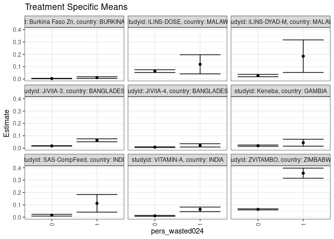

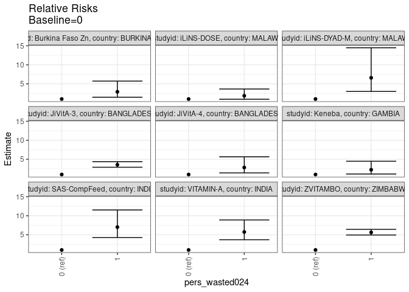

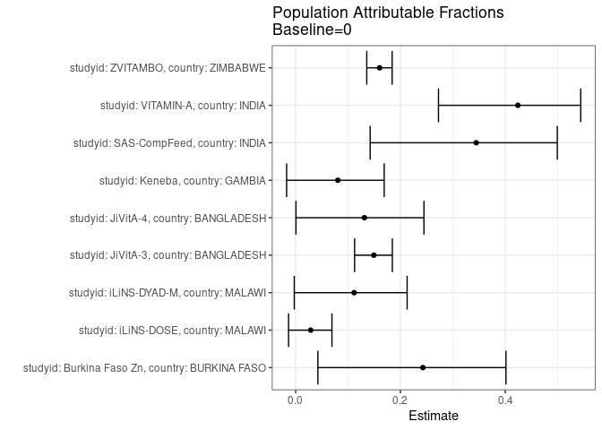

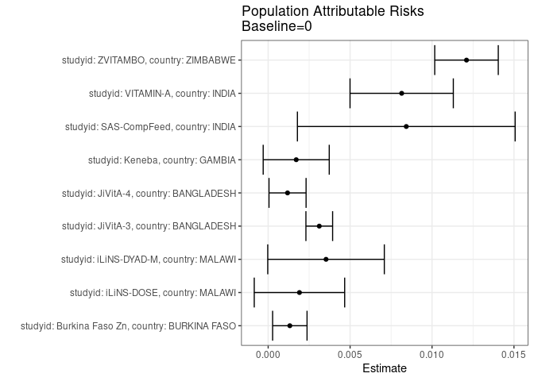

## Results Table

### Parameter: TSM

| studyid | country | intervention_level | baseline_level | estimate | ci_lower | ci_upper |
| --- | --- | --- | --- | --- | --- | --- |
| Burkina Faso Zn | BURKINA FASO | 0 | NA | 0.0041205 | 0.0025042 | 0.0057368 |
| Burkina Faso Zn | BURKINA FASO | 1 | NA | 0.0119830 | 0.0053848 | 0.0185811 |
| iLiNS-DOSE | MALAWI | 0 | NA | 0.0643777 | 0.0532333 | 0.0755221 |
| iLiNS-DOSE | MALAWI | 1 | NA | 0.1194030 | 0.0417391 | 0.1970669 |
| iLiNS-DYAD-M | MALAWI | 0 | NA | 0.0281090 | 0.0186260 | 0.0375921 |
| iLiNS-DYAD-M | MALAWI | 1 | NA | 0.1851852 | 0.0533715 | 0.3169988 |
| JiVitA-3 | BANGLADESH | 0 | NA | 0.0177679 | 0.0161560 | 0.0193798 |
| JiVitA-3 | BANGLADESH | 1 | NA | 0.0634699 | 0.0515702 | 0.0753696 |
| JiVitA-4 | BANGLADESH | 0 | NA | 0.0078204 | 0.0053059 | 0.0103348 |
| JiVitA-4 | BANGLADESH | 1 | NA | 0.0221822 | 0.0086824 | 0.0356820 |
| Keneba | GAMBIA | 0 | NA | 0.0195212 | 0.0143163 | 0.0247260 |
| Keneba | GAMBIA | 1 | NA | 0.0439024 | 0.0158519 | 0.0719530 |
| SAS-CompFeed | INDIA | 0 | NA | 0.0160264 | 0.0089046 | 0.0231482 |
| SAS-CompFeed | INDIA | 1 | NA | 0.1123693 | 0.0407896 | 0.1839491 |
| VITAMIN-A | INDIA | 0 | NA | 0.0110637 | 0.0074676 | 0.0146597 |
| VITAMIN-A | INDIA | 1 | NA | 0.0633933 | 0.0446160 | 0.0821705 |
| ZVITAMBO | ZIMBABWE | 0 | NA | 0.0634020 | 0.0592474 | 0.0675566 |
| ZVITAMBO | ZIMBABWE | 1 | NA | 0.3565216 | 0.3154698 | 0.3975734 |

### Parameter: E(Y)

| studyid | country | intervention_level | baseline_level | estimate | ci_lower | ci_upper |
| --- | --- | --- | --- | --- | --- | --- |
| Burkina Faso Zn | BURKINA FASO | NA | NA | 0.0054424 | 0.0037388 | 0.0071459 |
| iLiNS-DOSE | MALAWI | NA | NA | 0.0662869 | 0.0551877 | 0.0773861 |
| iLiNS-DYAD-M | MALAWI | NA | NA | 0.0316403 | 0.0217366 | 0.0415440 |
| JiVitA-3 | BANGLADESH | NA | NA | 0.0208859 | 0.0191395 | 0.0226323 |
| JiVitA-4 | BANGLADESH | NA | NA | 0.0090024 | 0.0064532 | 0.0115515 |
| Keneba | GAMBIA | NA | NA | 0.0212329 | 0.0160032 | 0.0264626 |
| SAS-CompFeed | INDIA | NA | NA | 0.0244547 | 0.0133604 | 0.0355490 |
| VITAMIN-A | INDIA | NA | NA | 0.0192111 | 0.0149047 | 0.0235174 |
| ZVITAMBO | ZIMBABWE | NA | NA | 0.0755055 | 0.0711204 | 0.0798906 |

### Parameter: RR

| studyid | country | intervention_level | baseline_level | estimate | ci_lower | ci_upper |
| --- | --- | --- | --- | --- | --- | --- |
| Burkina Faso Zn | BURKINA FASO | 0 | 0 | 1.000000 | 1.0000000 | 1.000000 |
| Burkina Faso Zn | BURKINA FASO | 1 | 0 | 2.908128 | 1.4791945 | 5.717440 |
| iLiNS-DOSE | MALAWI | 0 | 0 | 1.000000 | 1.0000000 | 1.000000 |
| iLiNS-DOSE | MALAWI | 1 | 0 | 1.854726 | 0.9461633 | 3.635747 |
| iLiNS-DYAD-M | MALAWI | 0 | 0 | 1.000000 | 1.0000000 | 1.000000 |
| iLiNS-DYAD-M | MALAWI | 1 | 0 | 6.588103 | 2.9968710 | 14.482807 |
| JiVitA-3 | BANGLADESH | 0 | 0 | 1.000000 | 1.0000000 | 1.000000 |
| JiVitA-3 | BANGLADESH | 1 | 0 | 3.572169 | 2.9147604 | 4.377851 |
| JiVitA-4 | BANGLADESH | 0 | 0 | 1.000000 | 1.0000000 | 1.000000 |
| JiVitA-4 | BANGLADESH | 1 | 0 | 2.836462 | 1.4213285 | 5.660559 |
| Keneba | GAMBIA | 0 | 0 | 1.000000 | 1.0000000 | 1.000000 |
| Keneba | GAMBIA | 1 | 0 | 2.248965 | 1.1254026 | 4.494251 |
| SAS-CompFeed | INDIA | 0 | 0 | 1.000000 | 1.0000000 | 1.000000 |
| SAS-CompFeed | INDIA | 1 | 0 | 7.011510 | 4.2663185 | 11.523112 |
| VITAMIN-A | INDIA | 0 | 0 | 1.000000 | 1.0000000 | 1.000000 |
| VITAMIN-A | INDIA | 1 | 0 | 5.729859 | 3.6916688 | 8.893345 |
| ZVITAMBO | ZIMBABWE | 0 | 0 | 1.000000 | 1.0000000 | 1.000000 |
| ZVITAMBO | ZIMBABWE | 1 | 0 | 5.623189 | 4.9269757 | 6.417782 |

### Parameter: PAR

| studyid | country | intervention_level | baseline_level | estimate | ci_lower | ci_upper |
| --- | --- | --- | --- | --- | --- | --- |
| Burkina Faso Zn | BURKINA FASO | 0 | NA | 0.0013219 | 0.0002715 | 0.0023722 |
| iLiNS-DOSE | MALAWI | 0 | NA | 0.0019092 | -0.0008499 | 0.0046683 |
| iLiNS-DYAD-M | MALAWI | 0 | NA | 0.0035313 | -0.0000256 | 0.0070881 |
| JiVitA-3 | BANGLADESH | 0 | NA | 0.0031180 | 0.0023035 | 0.0039325 |
| JiVitA-4 | BANGLADESH | 0 | NA | 0.0011820 | 0.0000507 | 0.0023133 |
| Keneba | GAMBIA | 0 | NA | 0.0017117 | -0.0003039 | 0.0037273 |
| SAS-CompFeed | INDIA | 0 | NA | 0.0084283 | 0.0017845 | 0.0150722 |
| VITAMIN-A | INDIA | 0 | NA | 0.0081474 | 0.0049956 | 0.0112992 |
| ZVITAMBO | ZIMBABWE | 0 | NA | 0.0121035 | 0.0101648 | 0.0140422 |

### Parameter: PAF

| studyid | country | intervention_level | baseline_level | estimate | ci_lower | ci_upper |
| --- | --- | --- | --- | --- | --- | --- |
| Burkina Faso Zn | BURKINA FASO | 0 | NA | 0.2428838 | 0.0424875 | 0.4013395 |
| iLiNS-DOSE | MALAWI | 0 | NA | 0.0288023 | -0.0134746 | 0.0693156 |
| iLiNS-DYAD-M | MALAWI | 0 | NA | 0.1116067 | -0.0025722 | 0.2127823 |
| JiVitA-3 | BANGLADESH | 0 | NA | 0.1492873 | 0.1125283 | 0.1845237 |
| JiVitA-4 | BANGLADESH | 0 | NA | 0.1312995 | 0.0006346 | 0.2448802 |
| Keneba | GAMBIA | 0 | NA | 0.0806155 | -0.0171560 | 0.1689889 |
| SAS-CompFeed | INDIA | 0 | NA | 0.3446496 | 0.1422343 | 0.4992991 |
| VITAMIN-A | INDIA | 0 | NA | 0.4240992 | 0.2726042 | 0.5440423 |
| ZVITAMBO | ZIMBABWE | 0 | NA | 0.1602995 | 0.1357623 | 0.1841400 |